# Praca domowa 2

Ilona Bednarz

Październik 17, 2018

## Wykres orginalny

Poniżej znajduje się wykres, który postanowiłam skomentować i poprawić. Wykres obrazuje poparcie, jakie uzyskały wiodące partie polityczne w Bawarii w dwóch ostatnich wyborach.

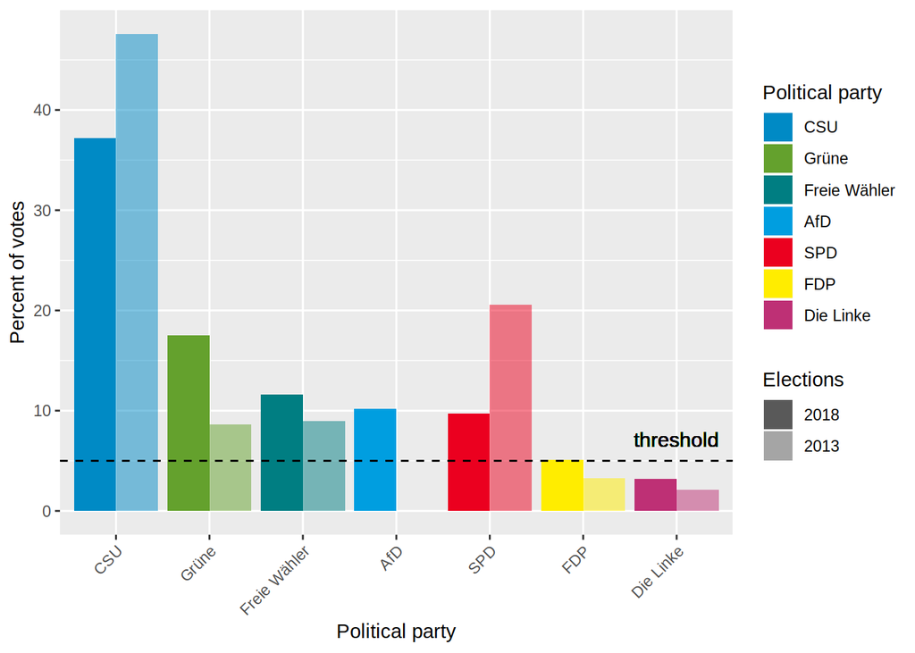

### Zalety

Pogrupowany wykres słupkowy jest dobrym sposobem na przedstawienie takich danych, ponieważ umożliwia porównywanie partii między sobą oraz odczytanie spadków i wzrostów poparcia dla poszczególnych partii. Sposób wykonania wykresu jest jednak możliwy do poprawy.

Dobrym pomysłem autora wykresu jest posortowanie partii według zdobytej liczby głosów w ostatnich wyborach oraz narysowanie poziomej linii obrazującej próg procentowy potrzebny do otrzymania mandatów, dzięki czemu widać, które partie weszły do sejmu zarówno w 2013 roku jak i w 2018 roku.

### Wady

Głównym problemem powyższego wykresu jest umieszczenie legendy wyjaśniającej przypisanie poszczególnych partii do kolorów słupków, ponieważ partie zostały podpisane na osi poziomej, a więc legenda taka nie jest potrzebna i tylko zaśmieca grafikę i utrudnia odbiór. Ponadto pojawia się druga legenda opisująca, do którego roku odnosi się dany słupek i jest ona jak najbardziej potrzebna, ale jej kolory nie odpowiadają kolorom słupków tylko ich ‘jasności’, co jest dosyć dziwnym zabiegiem.

Złym pomysłem (a raczej niedopatrzeniem) jest również przedstawienie słupków z późniejszych wyborów z lewej, a z wcześniejszych po prawej, ponieważ sugeruje to spadki poparcia, tam gdzie były wzrosty i na odwrót.

Ponadto dobrane kolory są bardzo jaskrawe, a słupek żółty mało czytelny.

## Wykres poprawiony

Poniżej prezentuję wykres, na którym poprawiłam wszystkie wymienione powyżej uchybienia.

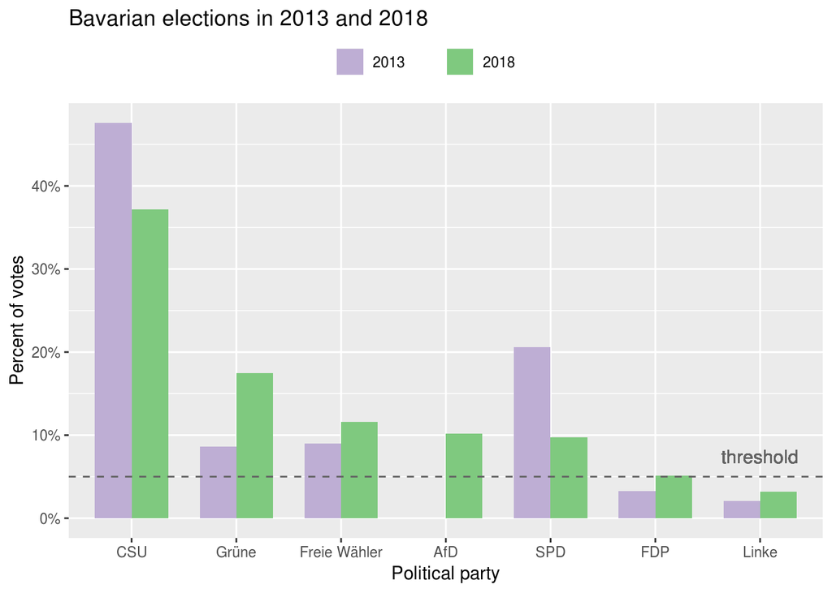

```r
ggplot(data = df, aes(x = party, y = votes)) +
  scale_x_discrete(limits = order) +
  geom_bar(aes(fill = Elections), stat = 'identity', position = 'dodge', width = 0.7) +
  geom_hline(yintercept = 5, color = '#636363', linetype="dashed") +
  scale_y_continuous(labels = function(x) paste0(x, "%")) +
  geom_text(aes(7, 5, label = "threshold", vjust = -1), size = 4, color = '#636363') +
  scale_fill_manual(values = c("#beaed4", "#7fc97f")) +
  labs(x = "Political party", y = "Percent of votes") +
  theme(legend.position = "top",
        legend.title = element_blank(),
        legend.text = element_text(margin = margin(r = 25, l = 5))) +
  ggtitle('Bavarian elections in 2013 and 2018')
```